© Guven

# Introduction to PyTorch

(source: Rao, Delip, and Brian McMahan. Natural Language Processing with PyTorch: Build Intelligent Language Applications Using Deep Learning. " O'Reilly Media, Inc.", 2019.)

## Introduction

**PyTorch** is a popular Python-based computational graph framework for implementing deep learning algorithms.

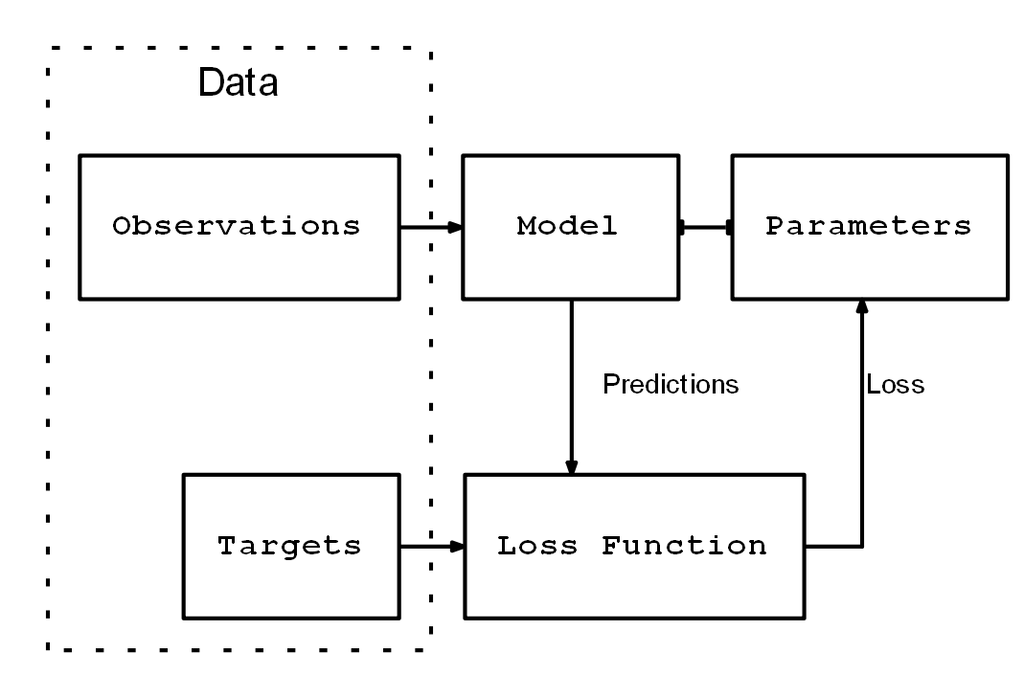

Sequence analysis or temporal information can be captured by a special class of artificial neural networks called recurrent neural networks (RNN), where connections between nodes form a directed graph along a sequence. Unlike feedforward neural networks, RNNs can use their internal state (memory) to process sequences of inputs. This makes them applicable to tasks such as unsegmented, connected speech recognition, and natural language processing. PyTorch stands out among other neural network frameworks because of its simpler programming and RNN capabilities.

The general machine learning pipelines can be seen as a data flow architecture where the input vectors are transformed by the model (a mathematical expression) to obtain predictions, and the loss function (e.g. the error difference between the intermediate model output and the actual desired output) to provide a feedback signal to adjust the parameters of the model. This data flow can be conveniently implemented using the computational graph data structure.

Technically, a computational graph is an abstraction that models mathematical expressions.

Consider the expression: $y=wx+b$

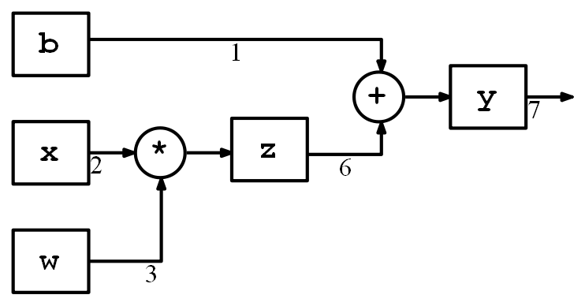

This equation can be written as two subexpressions, $z=wx$ and $y=z+b$.

We can then represent the original expression using a Directed Acyclic Graph (DAG) in which the nodes are the mathematical operators, e.g., multiplication and addition. The inputs to the operations are the incoming graph edges to the nodes, and the output of each operation is the outgoing edge.

## Basics

At the core of the PyTorch library is the tensor $\mathbf{T}$, a mathematical object holding multidimensional data.

A tensor of order zero is a scalar (e.g., a `real` number).

A tensor of order one ($\text{1}^\text{st}$ order tensor) is a one-dimensional vector or an array of $M$ many numbers, i.e., $\mathbf{T} \in \mathbb{R}^M$.

Similarly, a $\text{2}^\text{nd}$ order tensor is an array of vectors, or an $M \times M$ matrix, i.e. $\mathbf{T} \in \mathbb{R}^{M \times M}$.

Therefore, a tensor can be generalized as an n-dimensional array of scalars, i.e., $\text{n-dimensional tensor}=\mathbf{T} \in \mathbb{R}^{M \times M \times ... \times M}$

Note that, for simplicity, each data size is set to $M$ above, but this can be easily changed to any value in the PyTorch framework, similar to `numpy` multidimensional arrays.

## PyTorch Example Code Resources

Various PyTorch [examples](https://pytorch.org/examples/) covering a variety of ML solutions such as Convolutional Neural Networks, Variational Auto Encoders, Large Language Models, Vision Transformers, etc.

Associatied [Github](https://github.com/pytorch/examples) repository.

### Windows 10 (x64)

PyTorch:

https://pytorch.org/

Use a separate Anaconda environment for PyTorch:  
`conda create -n torch -c pytorch pytorch torchvision torchaudio cpuonly jupyter matplotlib pandas scikit-learn`↩  
`conda activate torch`↩

Run this notebook under the virtual environment `torch`

PyTorch API:

https://pytorch.org/docs/stable/index.html

```python
%matplotlib inline
import matplotlib.pyplot as plt
plt.rcParams["figure.dpi"] = 72
from IPython.display import display
import numpy as np

import torch

print(f'PyTorch version= {torch.__version__}')
print(f'CUDA available= {torch.cuda.is_available()}')  # CUDA optional - True when GPU present, CUDA installed
```

```
PyTorch version= 2.1.2
CUDA available= True
```

```python
# A helper function to display properties of the Python objects
def describe(_x):
    print(f"Type= {_x.type()}")
    print(f"Shape/size= {_x.shape}")
    print(f"Values= {_x}")

# Random tensor, has dummy values from the computer memory - not initialized
describe(torch.Tensor(2, 3))
```

```
Type= torch.FloatTensor
Shape/size= torch.Size([2, 3])
Values= tensor([[5.9442e+28, 1.7012e-42, 0.0000e+00],
        [0.0000e+00, 0.0000e+00, 0.0000e+00]])
```

```python
# Initialization
x = torch.ones(2, 3)
describe(x)

# Initialization
x.fill_(5)
describe(x)
```

```
Type= torch.FloatTensor
Shape/size= torch.Size([2, 3])
Values= tensor([[1., 1., 1.],
        [1., 1., 1.]])
Type= torch.FloatTensor
Shape/size= torch.Size([2, 3])
Values= tensor([[5., 5., 5.],
        [5., 5., 5.]])
```

```python
# Initialize from a numpy array
np_array = np.random.rand(2, 3)
describe(torch.from_numpy(np_array))
```

```
Type= torch.DoubleTensor
Shape/size= torch.Size([2, 3])
Values= tensor([[0.2016, 0.4183, 0.9953],
        [0.1251, 0.0591, 0.9326]], dtype=torch.float64)
```

```python
# Initialization using arange
x = torch.arange(6)
describe(x)
```

```
Type= torch.LongTensor
Shape/size= torch.Size([6])
Values= tensor([0, 1, 2, 3, 4, 5])
```

```python
# Convert shape (1,6) to shape (2,3)
x = x.view(2, 3)
describe(x)
```

```
Type= torch.LongTensor
Shape/size= torch.Size([2, 3])
Values= tensor([[0, 1, 2],
        [3, 4, 5]])
```

```python
# Sum values on dimension 0, i.e. vertically on columns
describe(torch.sum(x, dim=0))
```

```
Type= torch.LongTensor
Shape/size= torch.Size([3])
Values= tensor([3, 5, 7])
```

```python
# Sum values on dimension 1, i.e. horizontally on rows
describe(torch.sum(x, dim=1))
```

```
Type= torch.LongTensor
Shape/size= torch.Size([2])
Values= tensor([ 3, 12])
```

```python
# Transpose of the matrix
describe(torch.transpose(x, 0, 1))
```

```
Type= torch.LongTensor
Shape/size= torch.Size([3, 2])
Values= tensor([[0, 3],
        [1, 4],
        [2, 5]])
```

```python
# Slicing works similarly to numpy
describe(x)
describe(x[:1, :2])
```

```
Type= torch.LongTensor
Shape/size= torch.Size([2, 3])
Values= tensor([[0, 1, 2],
        [3, 4, 5]])
Type= torch.LongTensor
Shape/size= torch.Size([1, 2])
Values= tensor([[0, 1]])
```

## Computational Graphs

PyTorch tensor class encapsulates the data (the tensor itself) and a range of operations, such as algebraic operations, indexing, and reshaping operations. When the `requires_grad` Boolean flag is set to True on a tensor, bookkeeping operations are enabled that can track the gradient at the tensor and the gradient function, both of which are needed to facilitate gradient-based deep learning. Recall that a neural network is *trained* by minimizing the error between the output and the target output values by an optimization process where generally a gradient-based approach is used since the optimization problem is **non-convex** and requires a greedy optimization approach.

**Important:** Running the following cells multiple times will fail as the intermediate gradients are computed with the current data, and consecutive runs will receive no data.

```python
# Create a 2 by 2 matrix, all ones
x = torch.ones(2, 2, requires_grad=True)
describe(x)

print(x.grad is None)
```

```
Type= torch.FloatTensor
Shape/size= torch.Size([2, 2])
Values= tensor([[1., 1.],
        [1., 1.]], requires_grad=True)
True
```

```python
# Define a linear computation
y = (x+2) * (x+5) + 3
describe(y)

print(x.grad is None)
```

```
Type= torch.FloatTensor
Shape/size= torch.Size([2, 2])
Values= tensor([[21., 21.],
        [21., 21.]], grad_fn=<AddBackward0>)
True
```

```python
# Take mean of y, gradient is none
z = y.mean()
describe(z)

z.backward()

print(x.grad is None)
```

```
Type= torch.FloatTensor
Shape/size= torch.Size([])
Values= 21.0
False
```

When a tensor with `requires_grad=True` is created, PyTorch manages the bookkeeping that computes the gradients. First, PyTorch will keep track of the values of the forward pass. Then, at the end of the computations, a single scalar is used to compute a backward pass. The backward pass is initiated using the `backward()` method on a tensor resulting from evaluating a **loss function**. The backward pass computes a gradient value for a tensor object participating in the forward pass.

In general, the gradient is a value representing the slope of a function output with respect to the function input. In the computational graph, gradients exist for each model parameter and can be considered the parameter's contribution to the error signal. The gradients for the nodes in the computational graph are accessible by using the `.grad` member variable. Optimizers use the `.grad` variable to update the values of the parameters.

## Perceptron Re-visited

Each perceptron has an input $x$, an output $y$, and a set of weights $w$, a bias $b$, and an activation function $\mathrm{f}$. The weights and the bias are *learned* from the data, and the activation function is handpicked depending on the neural network model designer's intuition of the network and its target outputs.

$y = \mathrm{f}(wx+b)$

Generally more than one *feature* is used, thus $x \in \mathbb{R}^M$, $w \in \mathbb{R}^M$, and $b \in \mathbb{R}$, when there are $M$ features.

The activation function, denoted by $\mathrm{f}$, is typically a nonlinear function. Thus, a perceptron is a composition of a linear and a nonlinear function. The linear expression $wx+b$ is also known as the **affine transformation** which preserves points, straight lines, and planes. Some affine transformations include translation, scaling, reflection, rotation, etc., and their compositions.

```python
import torch.nn as nn

class Perceptron(nn.Module):
    """ A perceptron is one linear layer """
    def __init__(self, _input_dim):
        """
        Args:
            _input_dim (int): size of the input features
        """
        super().__init__()
        self.fc1 = nn.Linear(_input_dim, 1)

    def forward(self, _x_in):
        """ The forward pass of the perceptron
        Args:
            _x_in (torch.Tensor): an input data tensor
            _x_in.shape should be (batch, num_features)
        Returns:
            the resulting tensor. tensor.shape should be (batch,).
        """
        return torch.sigmoid(self.fc1(_x_in)).squeeze()
```

## Activation Functions

Activation functions are nonlinear decision-making stages that ensure the neural network can approximate a function that models the input-output relation.

### Sigmoid

$\mathrm{sigmoid}:(-\infty,\infty)\rightarrow[0,1]$   $\mathrm{sigmoid}(x)=\dfrac{1}{1+e^{-x}}$

### Tanh

$\mathrm{tanh}:(-\infty,\infty)\rightarrow[-1,1]$   $\mathrm{tanh}(x)=\dfrac{e^x-e^{-x}}{e^x+e^{-x}}$

### ReLU

The most popular activation function is also called a rectified linear unit.

$\mathrm{relu}:(-\infty,\infty) \rightarrow [0,\infty)$   $\mathrm{relu}(x)=\max(0,x)$

The clipping effect of ReLU that helps with the vanishing gradient problem can also become an issue where over time certain outputs in the network can become zero and never revive again. This is called the "dying ReLU" problem. To mitigate that effect, variants such as the Leaky ReLU and Parametric ReLU (PReLU) activation functions have been proposed, where the leak coefficient $a$ is a learned parameter.

PReLU: $\mathrm{f}(x)=\max(ax,x)$

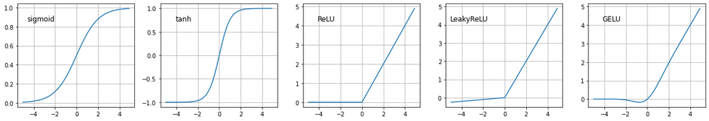

```python
x = torch.arange(-5, 5, .1)
y1 = torch.sigmoid(x)
y2 = torch.tanh(x)
y3 = torch.relu(x)
y4 = nn.functional.leaky_relu(x, negative_slope=0.05)
y5 = nn.functional.gelu(x)

plt.figure(figsize=(17, 3), dpi=72)

def plot(_i, _title, _x, _y):
    ax=plt.subplot(1, 5, _i); ax.grid(); plt.title(_title, x=0.2, y=0.8)
    ax.plot(_x.numpy(), _y.numpy())

plot(1, "sigmoid", x, y1)
plot(2, "tanh", x, y2)
plot(3, "ReLU", x, y3)
plot(4, "LeakyReLU", x, y4)
plot(5, "GELU", x, y5)

plt.tight_layout()
plt.show()
```

### Softmax

Like the sigmoid function, the softmax function squashes the output of each unit to be between 0 and 1. In addition, the softmax also divides each output by the sum of all the outputs, which gives us a discrete probability distribution over $K$ possible classes. The values in the resulting distribution all sum up to one, like a probability.

$\mathrm{softmax}(x_i)=\dfrac{e^{x_i}}{\sum\limits_{j=1}^{K}e^{x_j}}$

```python
# Check the softmax output
softmax = nn.Softmax(dim=1)
x_input = torch.randn(1, 3)
y_output = softmax(x_input)

print(x_input)
print(y_output)
print(torch.sum(y_output, dim=1))
```

```
tensor([[ 3.0762, -0.9544,  0.4197]])
tensor([[0.9192, 0.0163, 0.0645]])
tensor([1.0000])
```

## Loss Functions

Another piece we require to build learning computation graphs is the loss functions or objective functions. The training algorithm picks the correct (fitting) parameters by evaluating the loss function.

Recall that we have used a loss function as the sum of the difference between the truth $y$ and the (intermediate) prediction $\hat{y}$. The higher this difference, the worse the model prediction.

### Mean Squared Error Loss (L2)

Similar to linear regression, the network's output $\hat{y}$ and the target $y$ are real-valued number, and their difference is used as the loss/error/cost:

$\mathbf{L}_{\text{MSE}}=\frac{1}{n}\sum\limits_{i=1}^{n}{(y-\hat{y})^2}$

```python
# Demonstrate MSE loss
mse_loss = nn.MSELoss()
outputs = torch.randn(3, 5, requires_grad=True)
targets = torch.randn(3, 5)

loss = mse_loss(outputs, targets)

print(loss)
```

```
tensor(1.4016, grad_fn=<MseLossBackward0>)
```

### Categorical Cross-Entropy Loss

The categorical cross-entropy (CCE) loss is typically used in a multi-class classification problem in which the outputs are interpreted as predictions of class membership probabilities. The target $y$ is a vector of $K$ elements that represents the true multinomial distribution over all the classes. If only one class is correct or permitted, then this vector is a one-hot vector. The network's output $\hat{y}$ is also a vector of $K$ elements and represents the network's prediction of the multinomial distribution.

$\mathbf{L}_{\text{cross-entropy}}(y,\hat{y})=-\sum\limits_{c=1}^{K}{y_c\log(\hat{y}_c)}$

Best to use categorical cross-entropy in classification problems where only one result can be correct.

### Binary Cross-Entropy Loss

The binary cross-entropy (BCE) is the binary version of the CCE.

```python
# Demonstrate CCE loss
ce_loss = nn.CrossEntropyLoss()
outputs = torch.randn(3, 5, requires_grad=True)
targets = torch.tensor([1, 0, 3], dtype=torch.int64)

loss = ce_loss(outputs, targets)

print(loss)
```

```
tensor(1.3832, grad_fn=<NllLossBackward0>)
```

```python
# Demonstrate BCE loss
bce_loss = nn.BCELoss()
sigmoid = nn.Sigmoid()
probabilities = sigmoid(torch.randn(4, 1, requires_grad=True))
targets = torch.tensor([1, 0, 1, 0], dtype=torch.float32).view(4, 1)

loss = bce_loss(probabilities, targets)

print(probabilities)
print(loss)
```

```
tensor([[0.4829],
        [0.4700],
        [0.6641],
        [0.6877]], grad_fn=<SigmoidBackward0>)
tensor(0.7340, grad_fn=<BinaryCrossEntropyBackward0>)
```

### Loss Functions

Following table helps how to pick the correct loss function and the output layer (source: Textbook Raschka, 2019).

| Loss Function | Classification | Example Probability Output | Example Logit Output |
| --- | --- | --- | --- |
| `BinaryCrossEntropy` | binary | y_true= `[1]` y_pred= `[0.69]` | y_true= `[1]` y_pred= `[0.8]` |
| `CategoricalCrossEntropy` | multi-class | y_true= `[0,0,1]` y_pred= `[0.30,0.15,0.55]` | y_true= `[0,0,1]` y_pred= `[1.5,0.8,2.1]` |
| `SparseCategoricalCrossEntropy` | multi-class | y_true= `[2]` y_pred= `[0.30,0.15,0.55]` | y_true= `[2]` y_pred= `[1.5,0.8,2.1]` |

## Supervised Learning with PyTorch

Once the network is constructed and the loss function is picked, an optimizer is chosen that can update the model parameters and *fit* to the training data.

A single **hyperparameter** that controls the network parameter update behavior of the optimizer is called the learning rate `eta` which controls how much impact the error signal has on updating the weights.

Two popular optimizers in PyTorch are Stochastic Gradient Descent (SGD) and Adam.

```python
# Demonstrate the Adam optimizer
import torch.optim as optim

input_dim = 2
learning_rate = 0.001  # this must be found by a hyperparameter search

perceptron = Perceptron(input_dim)  # defined above
bce_loss = nn.BCELoss()  # Binary cross entropy loss
optimizer = optim.Adam(params=perceptron.parameters(), lr=learning_rate)

print(optimizer)
```

```
Adam (
Parameter Group 0
    amsgrad: False
    betas: (0.9, 0.999)
    capturable: False
    differentiable: False
    eps: 1e-08
    foreach: None
    fused: None
    lr: 0.001
    maximize: False
    weight_decay: 0
)
```

### Training

In batches, by a particular learning rate, for so many epochs:

1. Zero the gradients
2. Compute the output
3. Compute the loss
4. Use loss to produce gradients
5. Use optimizer to take gradient step

## Supervised Learning Example

Using Tf-Idf features, let's see how we classify programming languages.

The dataset is composed of Stackoverflow website (https://stackoverflow.com/) posts about 20 different programming languages.

We will use 1000 features to keep the classifier model small and still have very good results.

First, let's see the SVM performance:

```python
import pandas as pd
from sklearn.feature_extraction.text import TfidfVectorizer

df = pd.read_csv('/EP_datasets/stack_overflow_data.csv')
df = df[pd.notnull(df['tags'])]
print(f"Number of words= {df['post'].apply(lambda x: len(x.split(' '))).sum()}")

plCats = np.unique(df['tags'])
print(f"K categories={len(plCats):d} {plCats}")

X_tfidf = TfidfVectorizer(dtype=np.float32, max_features=1000).fit_transform(df.post).toarray()
print(f"N data points= {X_tfidf.shape[0]}, M features= {X_tfidf.shape[1]}")
```

```
Number of words= 10286120
K categories=20 ['.net' 'android' 'angularjs' 'asp.net' 'c' 'c#' 'c++' 'css' 'html' 'ios'
 'iphone' 'java' 'javascript' 'jquery' 'mysql' 'objective-c' 'php'
 'python' 'ruby-on-rails' 'sql']
N data points= 40000, M features= 1000
```

```python
def kfold_eval_docs(_clf, _Xdocs, _ydocs):
    from sklearn.model_selection import StratifiedKFold
    from sklearn.metrics import accuracy_score

    # Need indexable data structure
    accuracy = []
    kf = StratifiedKFold(n_splits=10, shuffle=True, random_state=0)
    for train_index, test_index in kf.split(_Xdocs, _ydocs):
        _clf.fit(_Xdocs[train_index], _ydocs[train_index])
        ypred = _clf.predict(_Xdocs[test_index])
        accuracy += [accuracy_score(_ydocs[test_index], ypred)]
    return np.array(accuracy)
```

```python
%%time

from sklearn.svm import LinearSVC

acc = kfold_eval_docs(LinearSVC(dual=True, class_weight='balanced'), X_tfidf, df.tags)

print(f"Linear SVM 10-fold CV accuracy= {np.mean(acc):.2f} {chr(177)}{np.std(acc):.3f}")
```

```
Linear SVM 10-fold CV accuracy= 0.79 ±0.006
CPU times: total: 19 s
Wall time: 18.9 s
```

Now, let's build the neural network classifier:

```python
import torch.nn as nn

class MyNetwork(nn.Module):
    """ A PyTorch neural network model """
    def __init__(self):
        super().__init__()
        self.fc1 = nn.Linear(1000, 100)  # A simple input layer, size M x Hsize
        self.fc2 = nn.Linear( 100, 100)  # A simple hidden layer, size Hsize x Hsize
        self.fc3 = nn.Linear( 100,  20)  # A simple output layer, size Hsize x K

    def forward(self, _x, apply_softmax=False):
        _x = nn.functional.relu(self.fc1(_x))
        _x = nn.functional.relu(self.fc2(_x))
        _x = self.fc3(_x)
        if apply_softmax:
            _x = nn.functional.softmax(_x, dim=1)
        return _x
```

```python
# Instantiate the neural network
Net1 = MyNetwork()
print(Net1)

# Set the learning rate - this part is magic of course
eta = 0.05
```

```
MyNetwork(
  (fc1): Linear(in_features=1000, out_features=100, bias=True)
  (fc2): Linear(in_features=100, out_features=100, bias=True)
  (fc3): Linear(in_features=100, out_features=20, bias=True)
)
```

Create the optimizer as Stochastic Gradient Descent.

```python
# Create a Stochastic Gradient Descent optimizer
optimizer = optim.SGD(Net1.parameters(), lr=eta, momentum=0.9)

# Create the loss function
loss_func = nn.CrossEntropyLoss()
```

Prepare the data arrays as Tensors.

**Important:** PyTorch requires class labels (integers) being `int64`, e.g. the `y` vector.

Also use a validation dataset to measure generalization performance (pulled as 10% of training dataset).

```python
from sklearn.model_selection import train_test_split

# Class labels (integers) are int64 for PyTorch
y_tfidf = np.array(df.tags.astype('category').cat.codes, dtype='int64')

# Use validation to measure generalization performance
X_train, X_test, y_train, y_test = train_test_split(X_tfidf, y_tfidf, test_size=0.3)
X_train, X_val, y_train, y_val = train_test_split(X_train, y_train, test_size=0.1)
```

```python
# Convert to tensors
X_train, y_train = torch.tensor(X_train), torch.tensor(y_train)
X_test, y_test = torch.tensor(X_test), torch.tensor(y_test)
X_val, y_val = torch.tensor(X_val), torch.tensor(y_val)
```

Define the prediction function which returns the class.

```python
def predict(_x):
    net_out = Net1.forward(_x, apply_softmax=True)
    p_values, indices = net_out.max(dim=1)
    return indices
```

Main training loop as in the following.

Note that `minibatch_size` is also to be determined by hyperparameter tuning.

```python
import sys

epochs=100
minibatch_size=1000

# The main training loop
for e in range(epochs):
    indices = np.arange(X_train.shape[0])
    for start_idx in range(0, indices.shape[0] - minibatch_size + 1, minibatch_size):
        batch_idx = indices[start_idx:start_idx + minibatch_size]
        # step 1.
        optimizer.zero_grad()
        # step 2.
        net_out = Net1.forward(X_train[batch_idx])
        # step 3.
        loss = loss_func(net_out, y_train[batch_idx])
        # step 4.
        loss.backward()
        # step 5.
        optimizer.step()

    y_pred = predict(X_train)
    y_val_pred = predict(X_val)

    train_acc = (torch.sum(y_train == y_pred).float() / X_train.shape[0])
    val_acc = (torch.sum(y_val == y_val_pred).float() / X_val.shape[0])

    sys.stderr.write(f"\r{e+1}/{epochs} | Cost: {loss:.2f} | Train/Valid Acc.: {train_acc*100:.2f}%/{val_acc*100:.2f}%")
    sys.stderr.flush()
```

```
100/100 | Cost: 0.44 | Train/Valid Acc.: 85.73%/77.11%
```

Let's see the performance on the testing dataset that was set aside.

```python
y_pred = predict(X_test)
test_acc = (torch.sum(y_test == y_pred).float() / X_test.shape[0])

print(f"Feedforward NN testing accuracy= {test_acc:.2f}")
```

```
Feedforward NN testing accuracy= 0.77
```

Now let's build the entire PyTorch based feedforward neural network as a Python class and measure it is 10-fold CV performance like we did for SVM.

```python
import numpy as np

import torch
import torch.nn as nn
import torch.optim as optim

class CustomMLP(nn.Module):
    """ A PyTorch neural network model """
    def __init__(self, n_hidden=30, epochs=100, eta=0.05, minibatch_size=50):
        super().__init__()
        self.n_hidden = n_hidden  # hidden layer size
        self.epochs = epochs  # number of learning iterations
        self.eta = eta  # learning rate
        self.minibatch_size = minibatch_size  # size of training batch - 1 would not work
        self.fc1, self.fc2, self.fc3 = None, None, None

    def _forward(self, X, apply_softmax=False):
        assert self.fc1 != None
        X = nn.functional.relu(self.fc1(X))
        X = nn.functional.relu(self.fc2(X))
        X = self.fc3(X)
        if apply_softmax:
            X = nn.functional.softmax(X, dim=1)
        return X

    def _reset(self):
        for m in self.modules():
            if isinstance(m, nn.Linear):
                 m.reset_parameters()

    def predict(self, _X):
        assert self.fc1 is not None
        net_out = self._forward(_X, apply_softmax=True)
        p_values, indices = net_out.max(dim=1)
        return indices

    def fit(self, X_train, y_train):
        self._reset()  # Reset the neural network weights
        n_output= np.unique(y_train).shape[0]  # number of class labels
        n_features= X_train.shape[1]

        self.fc1 = nn.Linear(n_features, self.n_hidden)  # A simple input layer
        self.fc2 = nn.Linear(self.n_hidden, self.n_hidden)  # A simple hidden layer
        self.fc3 = nn.Linear(self.n_hidden, n_output)  # A simple output layer

        optimizer = optim.SGD(self.parameters(), lr=self.eta, momentum=0.9)
        loss_func = nn.CrossEntropyLoss()

        for _ in range(self.epochs):
            indices = np.arange(X_train.shape[0])

            for start_idx in range(0, indices.shape[0] - self.minibatch_size + 1, self.minibatch_size):
                batch_idx = indices[start_idx:start_idx + self.minibatch_size]
                optimizer.zero_grad()

                net_out = self._forward(X_train[batch_idx])

                loss = loss_func(net_out, y_train[batch_idx])
                loss.backward()
                optimizer.step()
```

```python
%%time

clf = CustomMLP(100, 100, 0.05, 1000)

acc = kfold_eval_docs(clf, torch.tensor(X_tfidf), torch.tensor(y_tfidf))

print(f"PyTorch Feedforward NN 10-fold CV accuracy= {np.mean(acc):.2f} {chr(177)}{np.std(acc):.3f}")
```

```
PyTorch Feedforward NN 10-fold CV accuracy= 0.78 ±0.008
CPU times: total: 8min 49s
Wall time: 1min 17s
```

## A Simple Recurrent Neural Network

(source: PyTorch - Learning PyTorch with Examples)

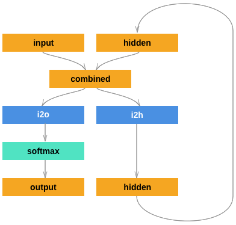

A simple RNN can be built by feeding back the output to the input through a **hidden** layer.

Consider 2 linear layers that operate on an input and a hidden state, with a `LogSoftmax` layer after the output as in the figure. The training is simply feeding the signal tensor together with the input and the preceding hidden output to feed the network. Since the signal is composed of a stream of features, such as $N^{(i)}$ number of data points and $M$ features, we will train the network with every signal $i$ with the hidden state and reset the hidden state between signals. The hidden state will hold the temporal knowledge the signal carries. Thus, the `train_signal` below is running the $N$ many data points of the signal `sxx`. The label `y` has a single value that corresponds to the class of `sxx`.

Other more advanced RNN layers, such as `nn.LSTM` and `nn.GRU` would improve the performance.

```python
import torch.nn as nn

class RNN(nn.Module):
    def __init__(self, n_features, n_hidden, n_output, eta=0.0005):
        super().__init__()

        self.n_features = n_features
        self.n_hidden = n_hidden

        self.i2h = nn.Linear(n_features + n_hidden, n_hidden)
        self.i2o = nn.Linear(n_features + n_hidden, n_output)
        self.softmax = nn.LogSoftmax(dim=1)

        self.eta = eta  # learning rate

        # loss function, since the last layer is nn.LogSoftmax
        self.criterion = nn.NLLLoss()


    def forward(self, x, hidden):
        combined = torch.cat((x, hidden), dim=1)
        hidden = self.i2h(combined)
        output = self.i2o(combined)
        output = self.softmax(output)
        return output, hidden

    def init_hidden(self):
        return torch.zeros(1, self.n_hidden)

    def train_signal(self, sxx, y):
        hidden = self.init_hidden()
        self.zero_grad()

        output = None
        T = sxx.shape[0]
        for i in range(T):  # i.e., for the duration of the signal
            output, hidden = self.forward(sxx[i].reshape(1,self.n_features), hidden)

        loss = self.criterion(output, y)
        loss.backward()

        for p in self.parameters():
            p.data.add_(-self.eta, p.grad.data)

        return output, loss.item()
```

## A Note on Data Structures

Many times we require shaping of tensors using the `numpy.reshape()` or `torch.view()`. It is important to note the row-major or column-major ordering:

- Python, PyTorch, Numpy, C++ languages, and compilers/interpreters have row-major order
- Matlab, Fortran have column-order

### Example

```python
# row-major order
A = torch.LongTensor(np.array([[1,2,3,4],[5,6,7,8]]))
print(A)
print(A.view(4,-1))
print(A.view(-1,2))
```

```
tensor([[1, 2, 3, 4],
        [5, 6, 7, 8]])
tensor([[1, 2],
        [3, 4],
        [5, 6],
        [7, 8]])
tensor([[1, 2],
        [3, 4],
        [5, 6],
        [7, 8]])
```

## References

1. Chintala, Soumith. "Deep learning with pytorch: A 60 minute blitz." (2017).
2. Rao, Delip, and Brian McMahan. Natural language processing with PyTorch: build intelligent language applications using deep learning. " O'Reilly Media, Inc.", 2019.
3. Why TensorFlow for Python is dying a slow death. https://thenextweb.com/news/why-tensorflow-for-python-is-dying-a-slow-death. Accessed May 2023.
4. PyTorch GitHub. https://github.com/pytorch. Accessed Oct 2023.

## Exercises

**Exercise 1.** Run the `CustomMLP` network on your notebook. If time permits, check the PyTorch API and add a dropout layer `torch.nn.Dropout` to your network by adding it in the `__init__` and updating `_forward`. Report its performance on the programming languages dataset.  
(Note that we have to turn off dropout for prediction)

```python
%%html
<style>
    table {margin-left: 0 !important;}
    p {font-family: verdana;}
    li {font-family: verdana;}
    div {font-size: 10pt;}
</style>
<!-- Display markdown tables left oriented in this notebook. -->
```